# Predicting Bike Share Usage in Philadlephia: A Space-Time Modeling Approach

Rujie Cheng

2025-05-03

# 1. Introduction to Bike Share System and Rebalancing Plans

Bike share programs provide short-term bicycle rentals through a network of docking stations, offering an affordable, eco-friendly, and flexible mode of urban transportation. These systems serve as a vital “first and last mile” solution, complementing public transit and reducing reliance on personal vehicles.

One of the key operational challenges for bike share systems is **“re-balancing”** — the process of redistributing bikes to ensure that docking stations are neither empty nor full. Without effective rebalancing, users may be unable to rent or return bikes, leading to reduced services reliability, system efficiency, and user dissatisfaction.

Rebalancing poses several operational challenges, including

- **Predicting Demand**: Usage varies by location and time, influenced by factors such as weather, special events, and commuting patterns.
- **Logistical Complexity**: Moving bikes efficiently between stations requires careful coordination of vehicles, staff, and real-time data.
- **Operational Costs**: Rebalancing involves expenses related to labor, vehicles, and equipment maintenance.

This project applies a space-time modeling approach to predict demand for Philadelphia’s bike share program, IndeGo. Launched in 2015, IndeGo currently operates over 250 stations and a fleet of more than 2,000 bikes, including both classic and pedal-assisted electric models. The system runs 24/7 and has logged over 8 million rides, helping replace more than 2 million car trips and supporting improved air quality and public health in the city.

The model developed in this project is intended to support rebalancing strategies. It assumes that rebalancing will be conducted via trucks relocating bikes between stations. This approach corresponds to a medium-term prediction window of 4 to 12 hours. As such, features like time of day, station location, and weather conditions play a critical role in accurately forecasting bike demand.

# 2. Data processing and Feature Engineering

## 2.1 Data Colletion & Feature Engineering

### 2.1.1 Bike Share Data

The bike share data used for model development comes from [IndeGo’s open data portal](https://www.rideindego.com/about/data/). I selected the Q4 2024 dataset (October - December) for analysis, as it captures a broader range of temperature variation, which is useful for studying weather-related impacts on ridership.

```r
dat <- read_csv("indego-trips-2024-q4.csv")
glimpse(dat)
```

[output not shown]

### 2.1.2 Collecting & Processing Census Data

In addition to trip-level bike share data, I incorporated socio-economic-related features at the census tract level from the 2022 5-Year ACS, These include total population, median household income, median age, White population, average travel time, number of commuters, commuting modes, and the number of public transit users.

Using these features, I derived indicators such as the percentage of White residents, mean commute time, and the share of residents who use public transportation. These contextual features help characterize the neighborhoods surrounding IndeGo stations and support more nuanced demand modeling across different parts of the city.

```r
PhillyCensus <-
  get_acs(geography = "tract",
          variables = c("B01003_001", "B19013_001",
                        "B02001_002", "B08013_001",
                        "B08012_001", "B08301_001",
                        "B08301_010", "B01002_001"),
          year = 2022,
          state = "PA",
          geometry = TRUE,
          county= "Philadelphia",
          output = "wide") %>%

  rename(Total_Pop =  B01003_001E,
         Med_Inc = B19013_001E,
         Med_Age = B01002_001E,
         White_Pop = B02001_002E,
         Travel_Time = B08013_001E,
         Num_Commuters = B08012_001E,
         Means_of_Transport = B08301_001E,
         Total_Public_Trans = B08301_010E) %>%

  select(Total_Pop, Med_Inc, White_Pop, Travel_Time,
         Means_of_Transport, Total_Public_Trans,
         Med_Age,
         GEOID, geometry) %>%

  mutate(Percent_White = White_Pop / Total_Pop,
         Mean_Commute_Time = Travel_Time / Total_Public_Trans,
         Percent_Taking_Public_Trans = Total_Public_Trans / Means_of_Transport)
```

```r
PhillyTracts <-
  PhillyCensus %>%
  as.data.frame() %>%
  distinct(GEOID, .keep_all = TRUE) %>%
  select(GEOID, geometry) %>%
  st_sf
```

### 2.1.3 Data Binning

To generate time-based variables, I binned the trip data into uniform one-hour intervals based on trip start times to make it easier to identify and analyze usage patterns over time.

```r
dat2 <- dat %>%
  filter(start_station != 3000 & end_station != 3000) %>%
  mutate(interval60 = floor_date(mdy_hm(start_time, tz = ""), unit = "hour"),
         week = week(interval60),
         dotw = wday(interval60, label = TRUE),
         month = month(interval60, label = TRUE))

glimpse(dat2)
```

```
## Rows: 293,910
## Columns: 19
## $ trip_id             <dbl> 1050296434, 1050293063, 1050296229, 1050276817, 10…
## $ duration            <dbl> 22, 8, 12, 1, 5, 9, 5, 6, 16, 16, 16, 39, 6, 40, 1…
## $ start_time          <chr> "10/1/2024 0:00", "10/1/2024 0:06", "10/1/2024 0:0…
## $ end_time            <chr> "10/1/2024 0:22", "10/1/2024 0:14", "10/1/2024 0:1…
## $ start_station       <dbl> 3322, 3166, 3007, 3166, 3075, 3166, 3030, 3010, 33…
## $ start_lat           <dbl> 39.93638, 39.97195, 39.94517, 39.97195, 39.96718, …
## $ start_lon           <dbl> -75.15526, -75.13445, -75.15993, -75.13445, -75.16…
## $ end_station         <dbl> 3375, 3017, 3244, 3166, 3102, 3008, 3203, 3163, 33…
## $ end_lat             <dbl> 39.96036, 39.98003, 39.93865, 39.97195, 39.96759, …
## $ end_lon             <dbl> -75.14020, -75.14371, -75.16674, -75.13445, -75.17…
## $ bike_id             <chr> "03580", "05386", "18082", "02729", "18519", "0272…
## $ plan_duration       <dbl> 365, 365, 365, 1, 30, 1, 365, 365, 30, 30, 30, 30,…
## $ trip_route_category <chr> "One Way", "One Way", "One Way", "Round Trip", "On…
## $ passholder_type     <chr> "Indego365", "Indego365", "Indego365", "Walk-up", …
## $ bike_type           <chr> "standard", "standard", "electric", "standard", "e…
## $ interval60          <dttm> 2024-10-01, 2024-10-01, 2024-10-01, 2024-10-01, 2…
## $ week                <dbl> 40, 40, 40, 40, 40, 40, 40, 40, 40, 40, 40, 40, 40…
## $ dotw                <ord> Tue, Tue, Tue, Tue, Tue, Tue, Tue, Tue, Tue, Tue, …
## $ month               <ord> Oct, Oct, Oct, Oct, Oct, Oct, Oct, Oct, Oct, Oct, …
```

```r
dat_census <- st_join(
  dat2 %>%
    filter(is.na(start_lat) == FALSE &
             is.na(start_lon) == FALSE &
             is.na(end_lat) == FALSE &
             is.na(end_lon) == FALSE) %>%
    st_as_sf(., coords = c("start_lon", "start_lat"), crs = 4326),
  PhillyTracts %>%
    st_transform(crs=4326),
  join=st_intersects,
  left = TRUE) %>%

  rename(Origin.Tract = GEOID) %>%
  mutate(start_lon = unlist(map(geometry, 1)),
         start_lat = unlist(map(geometry, 2)))%>%
  as.data.frame() %>%
  select(-geometry)%>%
  st_as_sf(., coords = c("end_lon", "end_lat"), crs = 4326) %>%
  st_join(., PhillyTracts %>%
            st_transform(crs=4326),
          join=st_intersects,
          left = TRUE) %>%
  rename(Destination.Tract = GEOID)  %>%
  mutate(end_lon = unlist(map(geometry, 1)),
         end_lat = unlist(map(geometry, 2)))%>%
  as.data.frame() %>%
  select(-geometry)
```

### 2.1.4 Collecting Weather Data

The weather data used in this analysis comes from Philadelphia Internal Airport. To align with the trip data, I collected hourly records of temperature, wind speed, and precipitation from October 1 to December 31, 2024.

```r
weather.Panel <-
  riem_measures(station = "PHL", date_start = "2024-10-01", date_end = "2024-12-31") %>%
  dplyr::select(valid, tmpf, p01i, sknt)%>%
  replace(is.na(.), 0) %>%
  mutate(interval60 = ymd_h(substr(valid,1,13))) %>%
  mutate(week = week(interval60),
         dotw = wday(interval60, label = TRUE),
         month = month(interval60, label = TRUE)) %>%
  mutate(month = fct_relevel(month, "October", "November", "December")) %>%
  group_by(interval60, month) %>%
  summarize(Temperature = max(tmpf),
            Precipitation = sum(p01i),
            Wind_Speed = max(sknt))# %>%
#mutate(Temperature = ifelse(Temperature == 0, 42, Temperature))

glimpse(weather.Panel)
```

```
## Rows: 2,184
## Columns: 5
## Groups: interval60 [2,184]
## $ interval60    <dttm> 2024-10-01 00:00:00, 2024-10-01 01:00:00, 2024-10-01 02…
## $ month         <ord> Oct, Oct, Oct, Oct, Oct, Oct, Oct, Oct, Oct, Oct, Oct, O…
## $ Temperature   <dbl> 67.0, 65.0, 65.0, 65.0, 65.0, 64.0, 64.4, 64.4, 64.0, 64…
## $ Precipitation <dbl> 0, 0, 0, 0, 0, 0, 0, 0, 0, 0, 0, 0, 0, 0, 0, 0, 0, 0, 0,…
## $ Wind_Speed    <dbl> 10, 8, 6, 8, 8, 6, 6, 7, 7, 9, 10, 8, 9, 10, 9, 12, 9, 1…
```

The following plot shows the weather conditions in Philadelphia during Q4 2024, including temperature, wind speed, and precipitation.

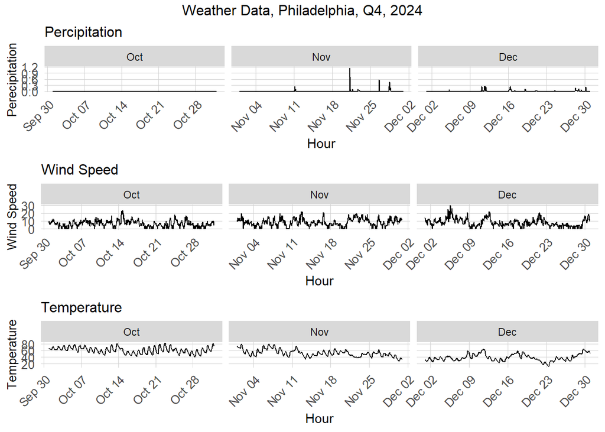

```r
grid.arrange(
  ggplot(weather.Panel, aes(interval60,Precipitation)) + geom_line() +
    labs(title="Percipitation", x="Hour", y="Perecipitation") +
    facet_wrap(vars(month), scales="free_x") +
    plotTheme,

  ggplot(weather.Panel, aes(interval60,Wind_Speed)) + geom_line() +
    labs(title="Wind Speed", x="Hour", y="Wind Speed") +
    facet_wrap(vars(month), scales = "free_x") +
    plotTheme,

  ggplot(weather.Panel, aes(interval60,Temperature)) + geom_line() +
    labs(title="Temperature", x="Hour", y="Temperature") +
    facet_wrap(vars(month), scales = "free_x") +
    plotTheme,

  top="Weather Data, Philadelphia, Q4, 2024",
  nrow = 3,
  heights = c(10,10,10))
```

## 2.2 Data Cleaning and Selection

During data processing, I removed trip records that were missing coordinates for either the start or end station, as they may reflect system tests or non-standard usage rather than actual user trips. In addition, trips with a start or end station ID of 3000 were excluded, as this represents a virtual station. Only trips that originated and ended at actual stations, with complete coordinate information for both points, were retained for analysis.

## 2.3 Exploratory Data Analysis

### 2.3.1 Overall Trips Across Different Hours

Philadelphia’s bike share usage shows clearly daily spikes in trip volume, reflecting regular commuting or activity patterns. Over the course of the three months, the total number of trips gradually decreases, which is reasonable given the seasonal drop in temperature during the final quarter of the year.

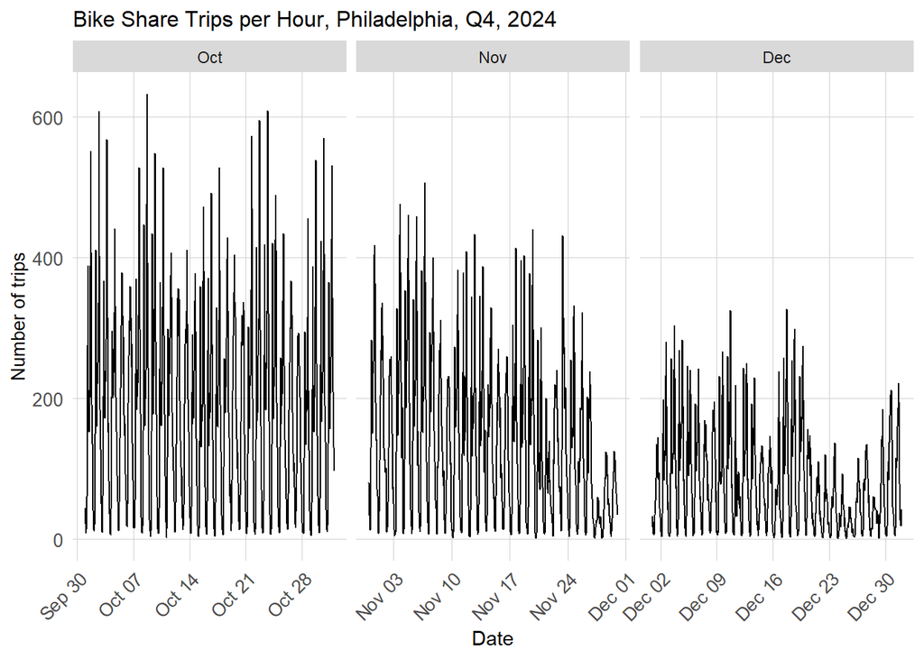

```r
ggplot(dat_census %>%
         group_by(interval60, month) %>%
         tally())+
  geom_line(aes(x = interval60, y = n))+
  labs(title="Bike Share Trips per Hour, Philadelphia, Q4, 2024",
       x="Date",
       y="Number of trips")+
  facet_wrap(vars(month), scales="free_x") +
  plotTheme
```

### 2.3.2 Mean number of Hourly Trips per Station

The following plots display the distribution of the mean number of hourly trips per starting station. The X-axis represents the average number of trips per hour originating from each station, while the Y-axis indicates the number of stations within each trip range. Data is grouped by four time intervals: Overnight (6 PM - 7 AM), AM Rush (7 - 10 AM), Mid-Day (10 AM - 3 PM), and PM Rush (3 - 6 PM).

Stations are generally most active during PM Rush hours, with the distribution shifting rightward, indicating higher trip volumes. AM Rush hours show a similar spread, though fewer stations average two or more trips per hour. During Mid-Day and Overnight periods, the distributions are more concentrated at lower values, with most stations averaging around one trip per hour.

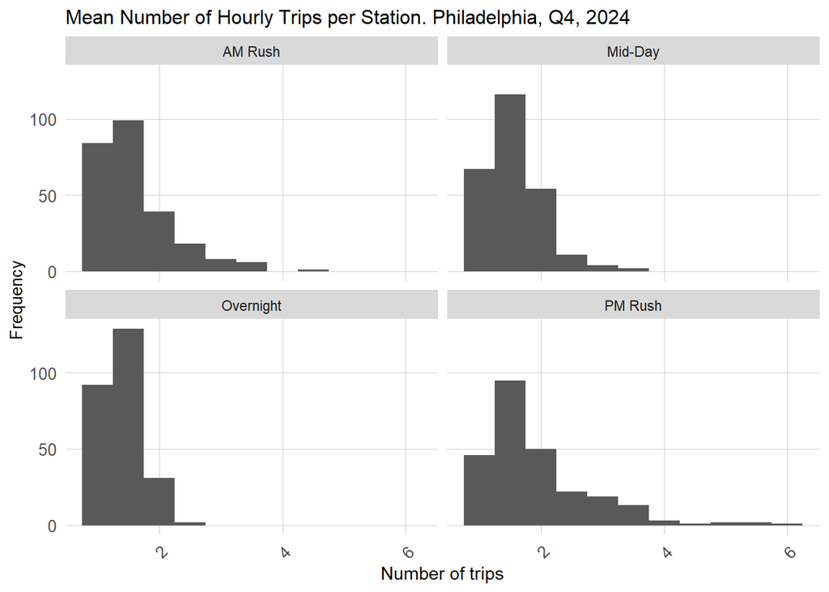

```r
dat_census %>%
  mutate(time_of_day = case_when(
    hour(interval60) < 7 | hour(interval60) > 18 ~ "Overnight",
    hour(interval60) >= 7 & hour(interval60) < 10 ~ "AM Rush",
    hour(interval60) >= 10 & hour(interval60) < 15 ~ "Mid-Day",
    hour(interval60) >= 15 & hour(interval60) <= 18 ~ "PM Rush"))%>%
  group_by(interval60, start_station, time_of_day) %>%
  tally()%>%
  group_by(start_station, time_of_day)%>%
  summarize(mean_trips = mean(n))%>%
  ggplot()+
  geom_histogram(aes(mean_trips), binwidth = 0.5)+
  labs(title="Mean Number of Hourly Trips per Station. Philadelphia, Q4, 2024",
       x="Number of trips",
       y="Frequency")+
  facet_wrap(~time_of_day)+
  plotTheme
```

### 2.3.3 Trips by Day of the Week

Grouping trips by day of the week reveals distinct usage patterns between weekdays and weekends. On weekdays, bike usage typically shows two peaks: one in the morning and another in the evening, corresponding to commuting hours. Monday and Friday tend to have lower overall usage, while Tuesday and Wednesday see the highest, likely due to hybrid work arrangements that allow employees to work from home at the beginning and end of the week.

On weekends, the pattern shifts to a single peak around mid-day, suggesting a different purpose for bike usage. These trends indicate that bike share primarily supports commuting during the week, while on weekends it is used more for recreational or casual trips.

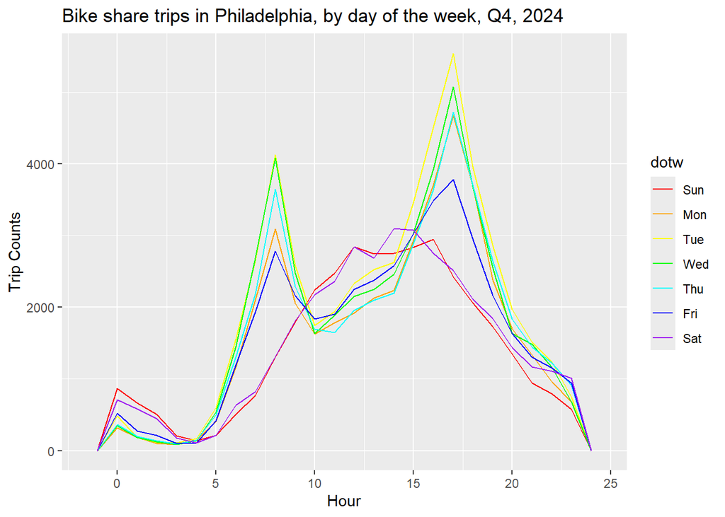

```r
ggplot(dat_census %>% mutate(hour = hour(interval60)))+
  geom_freqpoly(aes(hour, color = dotw), binwidth = 1)+
  labs(title="Bike share trips in Philadelphia, by day of the week, Q4, 2024",
       x="Hour", y="Trip Counts")+
  scale_color_manual(values = c("red","orange","yellow","green","cyan","blue","purple"))
```

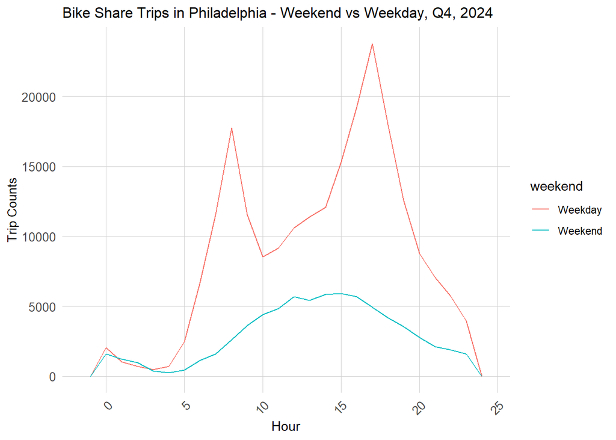

```r
ggplot(dat_census %>%
         mutate(hour = hour(interval60),
                weekend = ifelse(dotw %in% c("Sun", "Sat"), "Weekend", "Weekday")))+
     geom_freqpoly(aes(hour, color = weekend), binwidth = 1)+
  labs(title="Bike Share Trips in Philadelphia - Weekend vs Weekday, Q4, 2024",
       x="Hour",
       y="Trip Counts")+
     plotTheme
```

### 2.3.4 Map of Hourly Trips Starting from Each Station

The final series of maps displays the average number of hourly trips starting from each IndeGo station, grouped by day of the week and time of day. Overall, trip activity is higher on weekdays than on weekends, as shown by the darker-colored dots representing more active stations. Center City stands out as the most active area for trip origins, particularly during PM Rush hours on weekdays, reflecting its role as a major employment hub in Philadelphia.

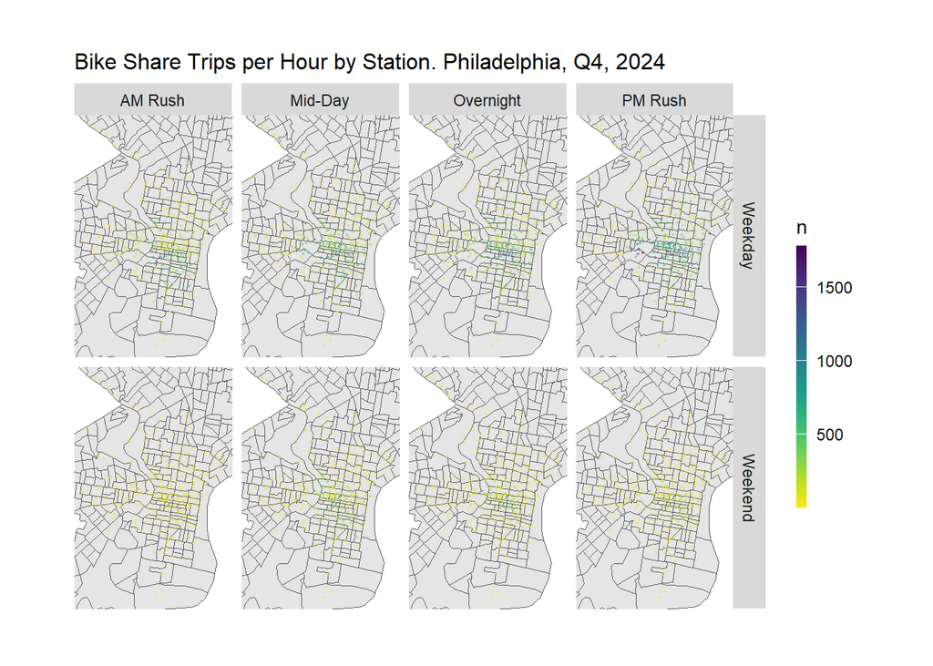

```r
ggplot()+
  geom_sf(data = PhillyTracts %>%
          st_transform(crs=4326))+
  geom_point(data = dat_census %>%
            mutate(hour = hour(interval60),
                weekend = ifelse(dotw %in% c("Sun", "Sat"), "Weekend", "Weekday"),
                time_of_day = case_when(
                  hour(interval60) < 7 | hour(interval60) > 18 ~ "Overnight",
                  hour(interval60) >= 7 & hour(interval60) < 10 ~ "AM Rush",
                  hour(interval60) >= 10 & hour(interval60) < 15 ~ "Mid-Day",
                  hour(interval60) >= 15 & hour(interval60) <= 18 ~ "PM Rush"))%>%
              group_by(start_station, start_lat, start_lon, weekend, time_of_day) %>%
              tally(),
            aes(x=start_lon, y = start_lat, color = n),
            fill = "transparent", alpha = 0.4, size = 0.3)+
  scale_colour_viridis(direction = -1,
  discrete = FALSE, option = "D")+
  ylim(min(dat_census$start_lat), max(dat_census$start_lat))+
  xlim(min(dat_census$start_lon), max(dat_census$start_lon))+
  facet_grid(weekend ~ time_of_day)+
  labs(title="Bike Share Trips per Hour by Station. Philadelphia, Q4, 2024")+
  mapTheme
```

# 3. Model Training and Validation

## 3.1 Creating the Space-Time Panel

A space-time model requires a complete panel covering every combination of time interval and location (in this case, bike share stations). To ensure this, I compared the theoretical number of combinations with the actual number generated using `expand.grid()`. The two values matched, confirming that each station-hour combination is represented, even if no trips occurred during that hour.

```r
#hour_interval <- seq(ISOdatetime(2024,10,1,0,0,0, tz=''), ISOdatetime(2024,12,31,23,59,59, tz = ''), by = "hour")
#hour_interval <- as.data.frame(hour_interval)

#station <- read_csv("indego-stations-2025-04-01.csv")
#station <- station %>%
  #filter(Station_ID > 3000)

length(unique(dat_census$interval60)) * length(unique(dat_census$start_station))
```

```
## [1] 563040
```

```r
study.panel <-
  expand.grid(interval60=unique(dat_census$interval60),
              start_station = unique(dat_census$start_station)) %>%
  left_join(., dat_census %>%
              select(start_station, Origin.Tract, start_lon, start_lat) %>%
              distinct() %>%
              group_by(start_station) %>%
              slice(1))

nrow(study.panel)
```

```
## [1] 563040
```

```r
ride.panel <- dat_census %>%
  mutate(Trip_Counter = 1) %>%
  right_join(study.panel) %>%
  group_by(interval60, start_station, Origin.Tract, start_lon, start_lat) %>%
  summarize(Trip_Count = sum(Trip_Counter, na.rm=T)) %>%
  left_join(weather.Panel) %>%
  ungroup() %>%
  filter(is.na(start_station) == FALSE) %>%
  mutate(week = week(interval60),
         dotw = wday(interval60, label = TRUE)) %>%
  filter(is.na(Origin.Tract) == FALSE)
```

```r
ride.panel <-
  left_join(ride.panel, PhillyCensus %>%
              as.data.frame() %>%
              select(-geometry), by = c("Origin.Tract" = "GEOID"))
```

## 3.2 Creating Time Lags

Time lag features were created based on the assumption that past demand influences future demand. Including lagged variables can enhance the predictive power of a time-space model by capturing temporal dependencies in bike usage patterns. The code below generates a set of hourly and daily lag features, as well as a holiday lag variable based on Thanksgiving Day.

```r
ride.panel <-
  ride.panel %>%
  arrange(start_station, interval60) %>%
  mutate(lagHour = dplyr::lag(Trip_Count,1),
         lag2Hours = dplyr::lag(Trip_Count,2),
         lag3Hours = dplyr::lag(Trip_Count,3),
         lag4Hours = dplyr::lag(Trip_Count,4),
         lag12Hours = dplyr::lag(Trip_Count,12),
         lag1day = dplyr::lag(Trip_Count,24),
         holiday = ifelse(yday(interval60) == 333,1,0)) %>% #Thanksgiving
   mutate(day = yday(interval60)) %>%
   mutate(holidayLag = case_when(dplyr::lag(holiday, 1) == 1 ~ "PlusOneDay",
                                 dplyr::lag(holiday, 2) == 1 ~ "PlusTwoDays",
                                 dplyr::lag(holiday, 3) == 1 ~ "PlusThreeDays",
                                 dplyr::lead(holiday, 1) == 1 ~ "MinusOneDay",
                                 dplyr::lead(holiday, 2) == 1 ~ "MinusTwoDays",
                                 dplyr::lead(holiday, 3) == 1 ~ "MinusThreeDays"),
         holidayLag = ifelse(is.na(holidayLag) == TRUE, 0, holidayLag))
```

```r
cor <- as.data.frame(ride.panel) %>%
  group_by(interval60) %>%
  summarise_at(vars(starts_with("lag"), "Trip_Count"), mean, na.rm = TRUE) %>%
  gather(Variable, Value, -interval60, -Trip_Count) %>%
  mutate(Variable = factor(Variable,
                           levels=c("lagHour","lag2Hours","lag3Hours",
                                    "lag4Hours","lag12Hours","lag1day"))
         ) %>%
  group_by(Variable) %>%
  summarize(correlation = round(cor(Value, Trip_Count),2))
cor
```

```
## # A tibble: 6 × 2
##   Variable   correlation
##   <fct>            <dbl>
## 1 lagHour           0.89
## 2 lag2Hours         0.7
## 3 lag3Hours         0.51
## 4 lag4Hours         0.36
## 5 lag12Hours       -0.31
## 6 lag1day           0.88
```

## 3.3 Data Splitting

To evaluate the model’s ability to generalize across time, the dataset was split into training and testing sets using a time-based approach. Data from the start of the quarter through the end of Week 50 were used for training, while data from the last three weeks of the year were reserved for testing. This split roughly corresponds to an 80-20 division.

```r
ride.Train <- filter(ride.panel, week <=50)
ride.Test <- filter(ride.panel, week > 50 )
ride.Test <- ride.Test %>%
  mutate(holiday = ifelse(yday(interval60) == 360,1,0)) %>% #Christmas
  mutate(day = yday(interval60)) %>%
  mutate(holidayLag = case_when(dplyr::lag(holiday, 1) == 1 ~ "PlusOneDay",
                                dplyr::lag(holiday, 2) == 1 ~ "PlusTwoDays",
                                dplyr::lag(holiday, 3) == 1 ~ "PlusThreeDays",
                                dplyr::lead(holiday, 1) == 1 ~ "MinusOneDay",
                                dplyr::lead(holiday, 2) == 1 ~ "MinusTwoDays",
                                dplyr::lead(holiday, 3) == 1 ~ "MinusThreeDays"),
         holidayLag = ifelse(is.na(holidayLag) == TRUE, 0, holidayLag))
```

## 3.4 Model Building & Training

Five models were developed to predict the number of trips starting from each station. The `purrr` package was used to train multiple models.

- **Model 1** is a time-based model that includes hour interval, day of the week, and temperature as predictors. It does not incorporate spatial variation, assuming usage patterns are consistent across the city.
- **Model 2** is a space-based model that includes start station and temperature but excludes time-related variables such as hour or day of the week.
- **Model 3** combines both spatial and temporal features along with weather variables (temperature and precipitation), allowing the model to capture variation across both time and space.
- **Model 4** extends Model 3 by incorporating temporal lag variables to account for short-term demand patterns.
- **Model 5** builds on Model 4 by adding indicators for holidays and holiday lags, capturing potential changes in ridership around major events.

```r
reg1 <-
  lm(Trip_Count ~  factor(hour(interval60)) + factor(dotw) + Temperature,  data=ride.Train)

reg2 <-
  lm(Trip_Count ~  factor(start_station) + Temperature,  data=ride.Train)

reg3 <-
  lm(Trip_Count ~  factor(start_station) + factor(hour(interval60)) + factor(dotw) + Temperature + Precipitation,
     data=ride.Train)

reg4 <-
  lm(Trip_Count ~  factor(start_station) +  factor(hour(interval60)) +
       factor(dotw) + Temperature + Precipitation +
       lagHour + lag2Hours +lag3Hours + lag4Hours + lag12Hours + lag1day,
     data=ride.Train)

reg5 <-
  lm(Trip_Count ~  factor(start_station) + factor(hour(interval60)) +
       factor(dotw) + Temperature + Precipitation +
       lagHour + lag2Hours +lag3Hours + + lag4Hours + lag12Hours + lag1day +
       holidayLag + holiday,
     data=ride.Train)
```

```r
ride.Test.weekNest <- ride.Test %>%
  nest(-week)
```

## 3.5 Model Validation

The table and chart below show the Mean Absolute Error of each model by week. Overall, all five models achieve relatively low MAE values on the testing dataset, indicating strong performance in predicting trip counts and generalizing to new data. On average, the predicted number of hourly bike trips per each station deviates from the observed number by less than one trip. The differences in MAE across models are modest, with Model 4 and 5 showing the lowest error rates. Taking both theoretical relevance and predictive performance into account, Model 5 appears to be the most suitable choice for forecasting bike share demand in Philadelphia.

```r
model_pred <- function(dat, fit){
   pred <- predict(fit, newdata = dat)}
```

```r
week_predictions <-
  ride.Test.weekNest %>%
    mutate(ATime_FE = map(.x = data, fit = reg1, .f = model_pred),
           BSpace_FE = map(.x = data, fit = reg2, .f = model_pred),
           CTime_Space_FE = map(.x = data, fit = reg3, .f = model_pred),
           DTime_Space_FE_timeLags = map(.x = data, fit = reg4, .f = model_pred),
           ETime_Space_FE_timeLags_holidayLags = map(.x = data, fit = reg5, .f = model_pred)) %>%
    gather(Regression, Prediction, -data, -week) %>%
    mutate(Observed = map(data, pull, Trip_Count),
           Absolute_Error = map2(Observed, Prediction,  ~ abs(.x - .y)),
           MAE = map_dbl(Absolute_Error, mean, na.rm = TRUE),
           sd_AE = map_dbl(Absolute_Error, sd, na.rm = TRUE))

week_predictions
```

```
## # A tibble: 15 × 8
##     week data     Regression      Prediction Observed Absolute_Error   MAE sd_AE
##    <dbl> <list>   <chr>           <list>     <list>   <list>         <dbl> <dbl>
##  1    51 <tibble> ATime_FE        <dbl>      <dbl>    <dbl [42,840]> 0.524 0.616
##  2    52 <tibble> ATime_FE        <dbl>      <dbl>    <dbl [42,840]> 0.458 0.430
##  3    53 <tibble> ATime_FE        <dbl>      <dbl>    <dbl [12,240]> 0.616 0.571
##  4    51 <tibble> BSpace_FE       <dbl>      <dbl>    <dbl [42,840]> 0.507 0.608
##  5    52 <tibble> BSpace_FE       <dbl>      <dbl>    <dbl [42,840]> 0.446 0.448
##  6    53 <tibble> BSpace_FE       <dbl>      <dbl>    <dbl [12,240]> 0.630 0.583
##  7    51 <tibble> CTime_Space_FE  <dbl>      <dbl>    <dbl [42,840]> 0.535 0.558
##  8    52 <tibble> CTime_Space_FE  <dbl>      <dbl>    <dbl [42,840]> 0.515 0.454
##  9    53 <tibble> CTime_Space_FE  <dbl>      <dbl>    <dbl [12,240]> 0.580 0.547
## 10    51 <tibble> DTime_Space_FE… <dbl>      <dbl>    <dbl [42,840]> 0.438 0.543
## 11    52 <tibble> DTime_Space_FE… <dbl>      <dbl>    <dbl [42,840]> 0.364 0.411
## 12    53 <tibble> DTime_Space_FE… <dbl>      <dbl>    <dbl [12,240]> 0.468 0.539
## 13    51 <tibble> ETime_Space_FE… <dbl>      <dbl>    <dbl [42,840]> 0.440 0.542
## 14    52 <tibble> ETime_Space_FE… <dbl>      <dbl>    <dbl [42,840]> 0.362 0.408
## 15    53 <tibble> ETime_Space_FE… <dbl>      <dbl>    <dbl [12,240]> 0.468 0.539
```

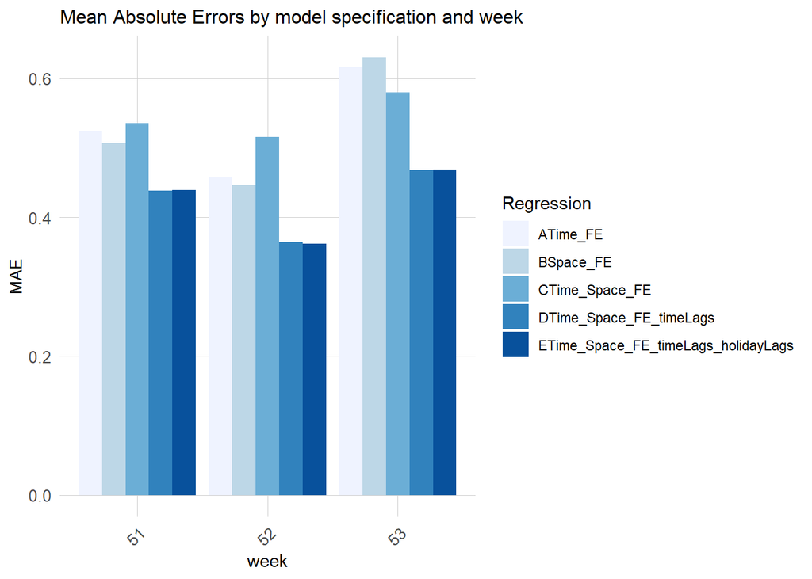

```r
week_predictions %>%
  dplyr::select(week, Regression, MAE) %>%
  gather(Variable, MAE, -Regression, -week) %>%
  ggplot(aes(week, MAE)) +
    geom_bar(aes(fill = Regression), position = "dodge", stat="identity") +
    scale_fill_manual(values = palette5) +
    labs(title = "Mean Absolute Errors by model specification and week") +
  plotTheme
```

# 4. Model Evaluation and Rebalancing Plan

## 4.1 Model Performance by Hour

The plot below shows observed vs predicted trip counts for each of the five models. The first time-based model tends to overemphasize hourly patterns and does not account for spatial variation, while the space-based model underestimates temporal variation in trip volume throughout the day. Compared to Models 3 and 4, Model 5 not only captures time-space dependencies, but also adjusts for holiday-related effects through lagged holiday features. However, Model 5 appears to underestimate bike usage on the nights around Christmas (likely December 25th or 26th) and overestimates usage on December 29th, suggesting room for improvement in capturing atypical demand fluctuations during holiday periods.

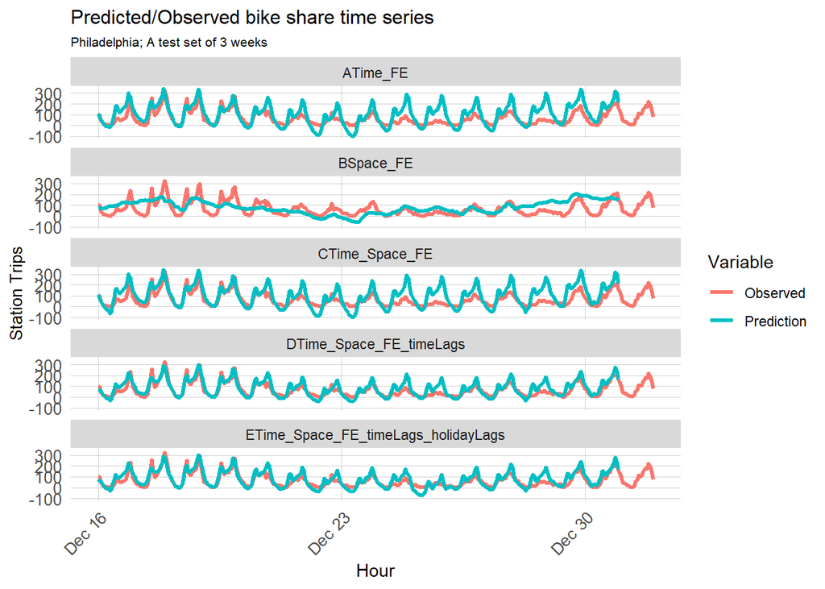

```r
week_predictions %>%
    mutate(interval60 = map(data, pull, interval60),
           start_station = map(data, pull, start_station)) %>%
    dplyr::select(interval60, start_station, Observed, Prediction, Regression) %>%
    unnest() %>%
    gather(Variable, Value, -Regression, -interval60, -start_station) %>%
    group_by(Regression, Variable, interval60) %>%
    summarize(Value = sum(Value)) %>%
    ggplot(aes(interval60, Value, colour=Variable)) +
      geom_line(size = 1.1) +
      facet_wrap(~Regression, ncol=1) +
      labs(title = "Predicted/Observed bike share time series", subtitle = "Philadelphia; A test set of 3 weeks",  x = "Hour", y= "Station Trips") +
      plotTheme
```

## 4.2 Model Performance by Station

The map below shows the mean absolute error of the testing set by station. The model tends to produce higher MAE values for stations closer to Center City. This pattern may be due to the higher variability and complexity of bike usage in the urban core. Stations near Center City serve a wide range of trip purposes including commuting, tourism, and recreation, making demand harder to predict.

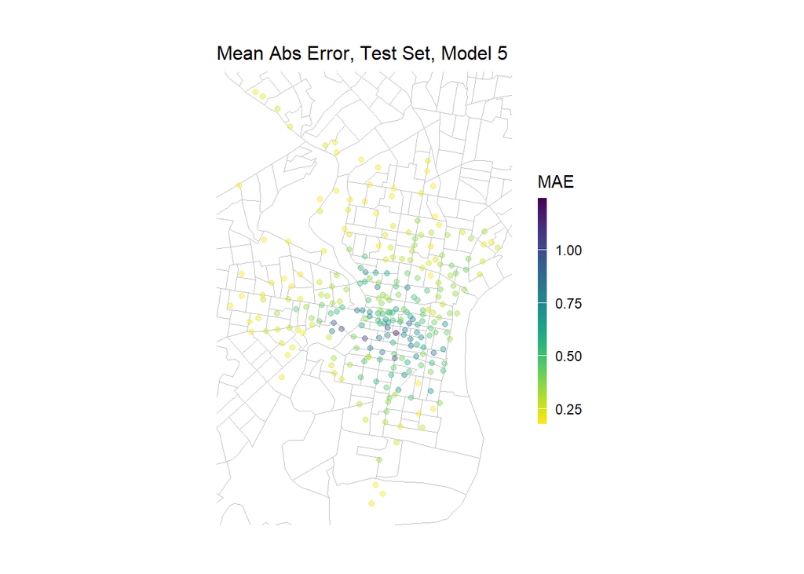

```r
week_predictions %>%
    mutate(interval60 = map(data, pull, interval60),
           start_station = map(data, pull, start_station),
           start_lat = map(data, pull, start_lat),
           start_lon = map(data, pull, start_lon)) %>%
    select(interval60, start_station, start_lon, start_lat, Observed, Prediction, Regression) %>%
    unnest() %>%
  filter(Regression == "ETime_Space_FE_timeLags_holidayLags") %>%
  group_by(start_station, start_lon, start_lat) %>%
  summarize(MAE = mean(abs(Observed-Prediction), na.rm = TRUE))%>%
ggplot(.)+
  geom_sf(data = PhillyCensus, color = "grey", fill = "transparent")+
  geom_point(aes(x = start_lon, y = start_lat, color = MAE),
             fill = "transparent", alpha = 0.4)+
  scale_colour_viridis(direction = -1,
  discrete = FALSE, option = "D")+
  ylim(min(dat_census$start_lat), max(dat_census$start_lat))+
  xlim(min(dat_census$start_lon), max(dat_census$start_lon))+
  labs(title="Mean Abs Error, Test Set, Model 5")+
  mapTheme
```

## 4.3 Model Performance by Time Intervals

The plot below compares observed and predicted trip counts in the testing dataset, grouped by time of day and day of the week. The black reference line represents a perfect prediction (slope = 1), where observed and predicted values are equal. The red lines indicate the model’s actual performance. Across all time intervals and days, the model tends to underestimate demand.

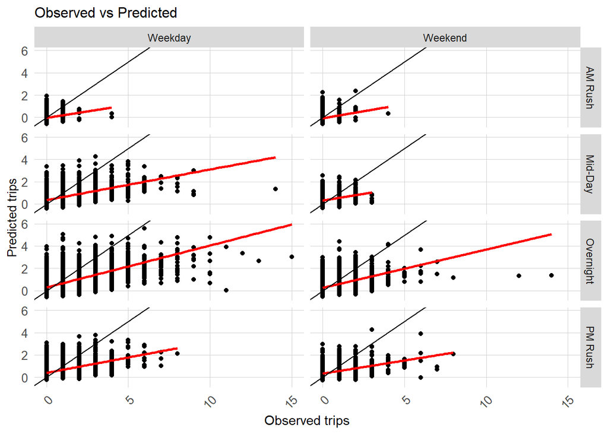

```r
week_predictions %>%
    mutate(interval60 = map(data, pull, interval60),
           start_station = map(data, pull, start_station),
           start_lat = map(data, pull, start_lat),
           start_lon = map(data, pull, start_lon),
           dotw = map(data, pull, dotw)) %>%
    select(interval60, start_station, start_lon, start_lat,
           Observed, Prediction, Regression, dotw) %>%
    unnest() %>%
  filter(Regression == "ETime_Space_FE_timeLags_holidayLags")%>%
  mutate(weekend = ifelse(dotw %in% c("Sun", "Sat"), "Weekend", "Weekday"),
         time_of_day = case_when(
           hour(interval60) < 7 | hour(interval60) > 18 ~ "Overnight",
           hour(interval60) >= 7 & hour(interval60) < 10 ~ "AM Rush",
           hour(interval60) >= 10 & hour(interval60) < 15 ~ "Mid-Day",
           hour(interval60) >= 15 & hour(interval60) <= 18 ~ "PM Rush"
           )) %>%
  ggplot()+
  geom_point(aes(x= Observed, y = Prediction))+
    geom_smooth(aes(x= Observed, y= Prediction), method = "lm", se = FALSE, color = "red")+
    geom_abline(slope = 1, intercept = 0)+
  facet_grid(time_of_day~weekend) +
  labs(title="Observed vs Predicted",
       x="Observed trips",
       y="Predicted trips") +
  plotTheme
```

## 4.4 Model Performance by Time Intervals and Station

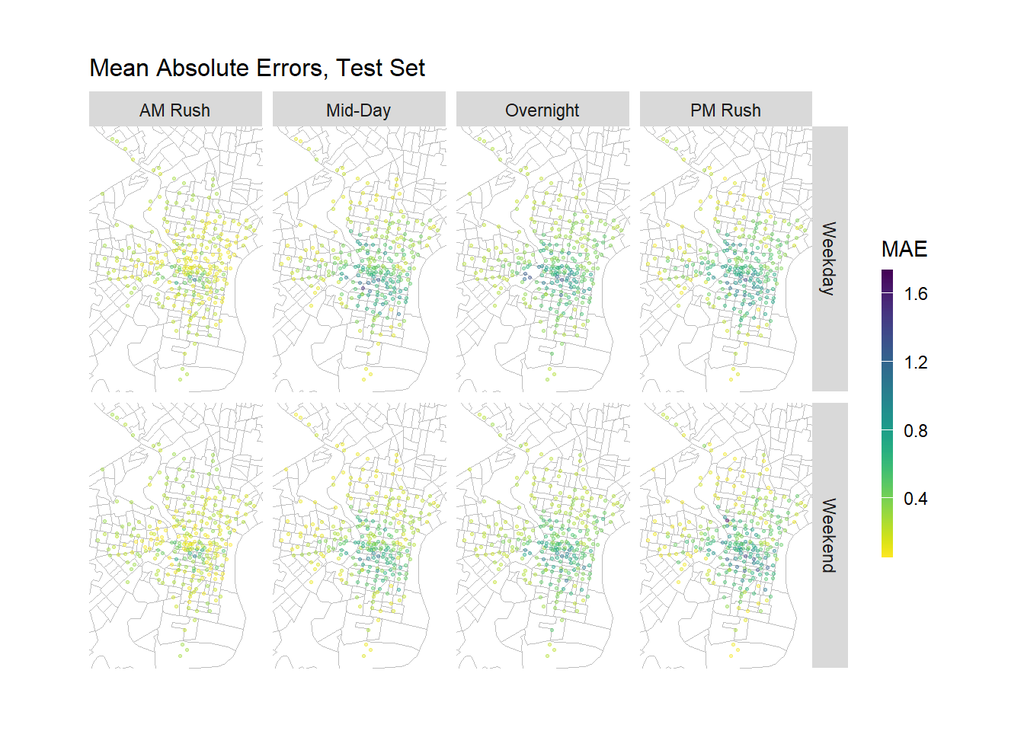

```r
week_predictions %>%
    mutate(interval60 = map(data, pull, interval60),
           start_station = map(data, pull, start_station),
           start_lat = map(data, pull, start_lat),
           start_lon = map(data, pull, start_lon),
           dotw = map(data, pull, dotw) ) %>%
    select(interval60, start_station, start_lon, start_lat, Observed, Prediction, Regression,
           dotw) %>%
    unnest() %>%
  filter(Regression == "ETime_Space_FE_timeLags_holidayLags")%>%
  mutate(weekend = ifelse(dotw %in% c("Sun", "Sat"), "Weekend", "Weekday"),
         time_of_day = case_when(
           hour(interval60) < 7 | hour(interval60) > 18 ~ "Overnight",
           hour(interval60) >= 7 & hour(interval60) < 10 ~ "AM Rush",
           hour(interval60) >= 10 & hour(interval60) < 15 ~ "Mid-Day",
           hour(interval60) >= 15 & hour(interval60) <= 18 ~ "PM Rush"
           )) %>%
  group_by(start_station, weekend, time_of_day, start_lon, start_lat) %>%
  summarize(MAE = mean(abs(Observed-Prediction), na.rm = TRUE)) %>%
  ggplot(.)+
  geom_sf(data = PhillyCensus, color = "grey", fill = "transparent")+
  geom_point(aes(x = start_lon, y = start_lat, color = MAE),
             fill = "transparent", size = 0.5, alpha = 0.4)+
  scale_colour_viridis(direction = -1,
  discrete = FALSE, option = "D")+
  ylim(min(dat_census$start_lat), max(dat_census$start_lat))+
  xlim(min(dat_census$start_lon), max(dat_census$start_lon))+
  facet_grid(weekend~time_of_day)+
  labs(title="Mean Absolute Errors, Test Set")+
  mapTheme
```

## 4.5 Prediction Errors by Socio-economic Variables

The following plot shows the MAE values by three socio-economic variables at the census tract level: median household income, percentage of residents commuting by public transportation, and percentage of White population. The results indicate that prediction errors are not evenly distributed across neighborhoods with different socio-economic conditions. The model performs better in census tracts with higher median household income and a higher percentage of White residents, while performance worsens in areas with a larger share of public transit commuters. This pattern may reflect differences in usage patterns. Wealthier residents may use bike share services more frequently, making them better represented in the trip dataset. As a result, demand in these areas tends to be more consistent and easier to predict.

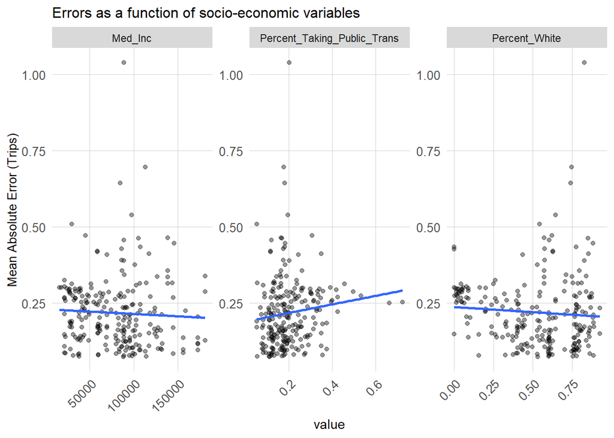

```r
week_predictions %>%
    mutate(interval60 = map(data, pull, interval60),
           start_station = map(data, pull, start_station),
           start_lat = map(data, pull, start_lat),
           start_lon = map(data, pull, start_lon),
           dotw = map(data, pull, dotw),
           Percent_Taking_Public_Trans = map(data, pull, Percent_Taking_Public_Trans),
           Med_Inc = map(data, pull, Med_Inc),
           Percent_White = map(data, pull, Percent_White)) %>%
    select(interval60, start_station, start_lon, start_lat, Observed, Prediction, Regression,
           dotw, Percent_Taking_Public_Trans, Med_Inc, Percent_White) %>%
    unnest() %>%
  filter(Regression == "ETime_Space_FE_timeLags_holidayLags")%>%
  mutate(weekend = ifelse(dotw %in% c("Sun", "Sat"), "Weekend", "Weekday"),
         time_of_day = case_when(
           hour(interval60) < 7 | hour(interval60) > 18 ~ "Overnight",
           hour(interval60) >= 7 & hour(interval60) < 10 ~ "AM Rush",
           hour(interval60) >= 10 & hour(interval60) < 15 ~ "Mid-Day",
           hour(interval60) >= 15 & hour(interval60) <= 18 ~ "PM Rush")) %>%
  filter(time_of_day == "AM Rush") %>%
  group_by(start_station, Percent_Taking_Public_Trans, Med_Inc, Percent_White) %>%
  summarize(MAE = mean(abs(Observed-Prediction), na.rm = TRUE))%>%
  gather(-start_station, -MAE, key = "variable", value = "value")%>%
  ggplot(.)+
  geom_point(aes(x = value, y = MAE), alpha = 0.4)+
  geom_smooth(aes(x = value, y = MAE), method = "lm", se= FALSE)+
  facet_wrap(~variable, scales = "free")+
  labs(title="Errors as a function of socio-economic variables",
       y="Mean Absolute Error (Trips)")+
  plotTheme
```

To sum up, the model’s station-level and time-specific demand predictions can inform rebalancing strategies by highlighting where and when supply-demand mismatches are most likely to occur. Error patterns indicate that the model tends to underestimate demand during Overnight and PM Rush hours, especially in Center Cit. These areas, being job and transit hubs, experience more volatile usage, making them priority zones for proactive rebalancing.

Additionally, model performance varies across neighborhoods with different socio-economic characteristics. Stations in higher-income, majority-White census tracts exhibit lower prediction errors, suggesting more stable and predictable usage patterns. In contrast, areas with a higher share of public transit commuters show higher MAEs, indicating greater uncertainty in demand. Rebalancing strategies can use this insight to build in more flexible, responsive operations in these harder-to-predict neighborhoods—such as dynamic monitoring or on-call redistribution.

By aligning truck schedules with predicted spikes in demand and known error-prone areas, the model supports more efficient and equitable rebalancing across Philadelphia’s bike-share network.

# 5. Conclusion and Discussion

## 5.1 Model Strengths and Effectiveness

This project developed a space-time model to forecast hourly bike demand at the station level for Philadelphia’s IndeGo bike share system. Among the five tested models, Model 5 — incorporating spatial, temporal, weather, time-lag, and holiday features — performed the best overall. All models achieved low MAEs on the testing dataset, with average prediction errors falling within one trip per station-hour. This level of accuracy makes the model a useful tool for supporting Indego’s operational planning, particularly for improving rebalancing strategies.

The model is especially useful for identifying time periods and locations with a high likelihood of supply-demand mismatches, enabling more efficient and data-driven rebalancing strategies. Error patterns reveal consistent underestimation during PM Rush and Overnight hours, particularly around Center City, where demand is more volatile. These insights can guide truck dispatch based on anticipated demand, allowing operators to proactively allocate resources to stations with frequent over- or under-supply. Aligning operational schedules with predicted peak-error periods can improve overall system reliability and enhance user satisfaction.

Additionally, by identifying neighborhoods with highly variable demand, the model can support more adaptive strategies, such as real-time monitoring or deploying flexible rebalancing crews. Over time, the model can also serve as a strategic planning tool, helping assess the impact of seasonal trends, holiday effects, or potential network expansions.

## 5.2 Challenges and Limitations

Despite its strong overall performance, the model has several limitations:

- **Equity Concerns**: Model accuracy varies across socio-economic contexts. It performs better in wealthier, predominantly White census tracts where bike usage is more regular. In contrast, tracts with higher shares of public transit commuters show higher prediction errors. This suggests the model could be improved by incorporating variables that capture neighborhood-level differences in biking behavior or infrastructure.
- **Coarse Weather Resolution**: The weather data used in the model were sourced from Philadelphia International Airport and applied uniformly across all stations. This approach may fail to capture local microclimates or spatial variability in weather conditions, which can influence ridership in different parts of the city. Incorporating interpolated weather data or sourcing from multiple observations points could improve the spatial precision of the model.
- **Lack of Dock Availability Data**: The model does not include dock availability as a predictor because such data are not provided in Indego’s public dataset. Dock availability can significantly affect trip behavior, especially during peak periods when stations may be full or empty. Including this feature in future models—if data become available—could enhance predictive performance and operational relevance.
- **Model Type and Flexibility**: The current model is structured as a generalized linear model. While interpretable and efficient, it may not fully capture non-linear relationships or complex interactions. Future work could explore more flexible modeling techniques to improve prediction in areas with highly variable demand.